# Лабораторная работа №5

Конфигурирование VLAN

Владимир Базлов

Российский университет дружбы народов, Москва, Россия

08 марта 2026

# Цель работы

## Основная цель

Получить основные навыки по настройке VLAN на коммутаторах сети.

# Настройка IP-адресов

## Топология сети

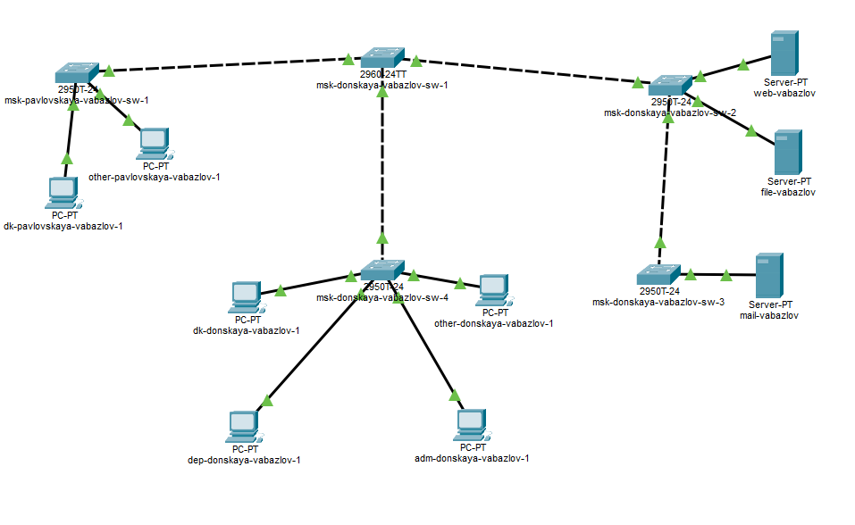

Топология сети в Cisco Packet Tracer

## Настройка IP на ПК

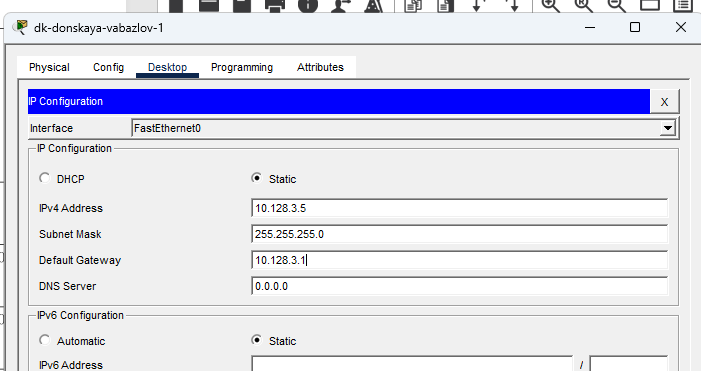

Настройка IP-адреса

## Примеры адресации узлов

- dk-donskaya-vabazlov-1 — 10.128.3.5/24
- dk-pavlovskaya-vabazlov-1 — 10.128.3.10/24
- dep-donskaya-vabazlov-1 — 10.128.4.5/24
- adm-donskaya-vabazlov-1 — 10.128.5.5/24
- other-donskaya-vabazlov-1 — 10.128.6.5/24
- other-pavlovskaya-vabazlov-1 — 10.128.6.10/24

# Настройка VLAN и VTP

## VTP-сервер и создание VLAN

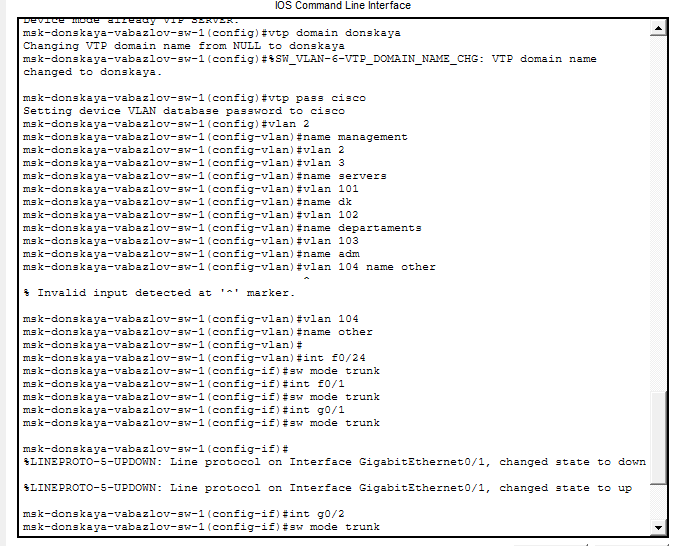

Настройка VTP-сервера и создание VLAN

## Созданные VLAN

- VLAN 2 — management
- VLAN 3 — servers
- VLAN 101 — dk
- VLAN 102 — departments
- VLAN 103 — adm
- VLAN 104 — other

## Настройка VTP-клиента

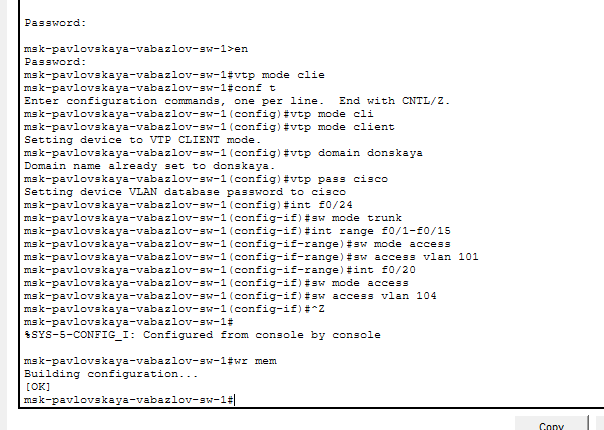

Настройка VTP-клиента

## Назначение VLAN на коммутаторах

- msk-pavlovskaya-sw-1:
  - Fa0/1–Fa0/15 → VLAN 101
  - Fa0/20 → VLAN 104
- msk-donskaya-sw-2:
  - Fa0/1–Fa0/2 → VLAN 3
- msk-donskaya-sw-3:
  - Fa0/1–Fa0/2 → VLAN 3
- msk-donskaya-sw-4:
  - Fa0/1–Fa0/5 → VLAN 101
  - Fa0/6–Fa0/10 → VLAN 102
  - Fa0/11–Fa0/15 → VLAN 103
  - Fa0/16–Fa0/20 → VLAN 104

# Настройка Trunk-портов

## Магистральные соединения

- На msk-donskaya-sw-1 trunk настроен на:
  - FastEthernet0/24
  - FastEthernet0/1
  - GigabitEthernet0/1
  - GigabitEthernet0/2
- На клиентских коммутаторах trunk используется для передачи нескольких VLAN между устройствами.

## Настройка VLAN на коммутаторе доступа

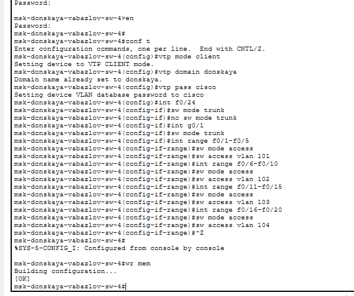

Настройка VLAN на коммутаторе msk-donskaya-sw-4

# Проверка связности

## Проверка ping внутри и между VLAN

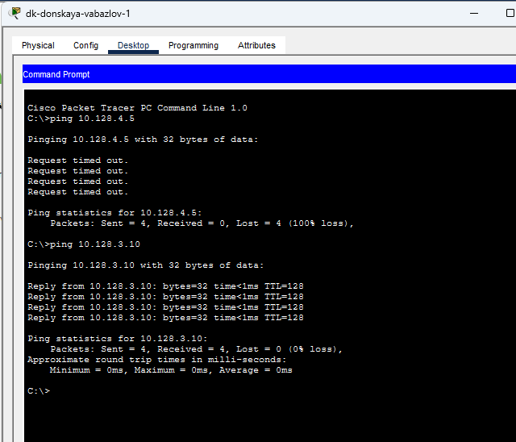

Проверка доступности устройств командой ping

## Результаты проверки

- узлы из одной VLAN успешно обмениваются ICMP-пакетами;
- узлы из разных VLAN недоступны;
- межвлановая маршрутизация в данной топологии не настроена.

## Дополнительная проверка

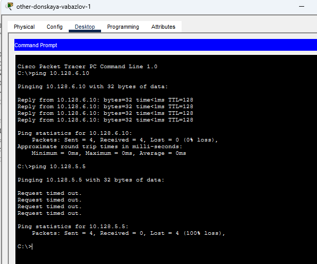

Проверка доступности устройств внутри VLAN

# Анализ передачи ICMP

## Режим Simulation

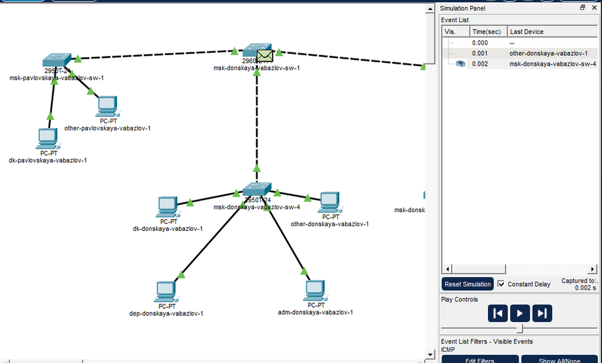

Передача пакета в режиме Simulation

## Структура ICMP-запроса

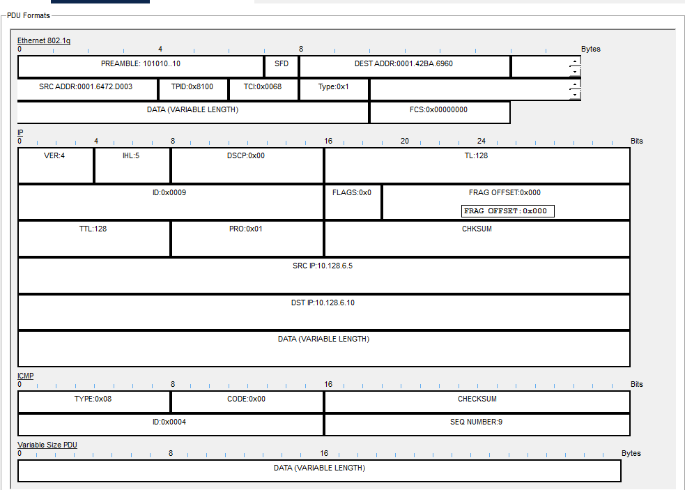

Структура ICMP-запроса

## Структура ICMP-ответа

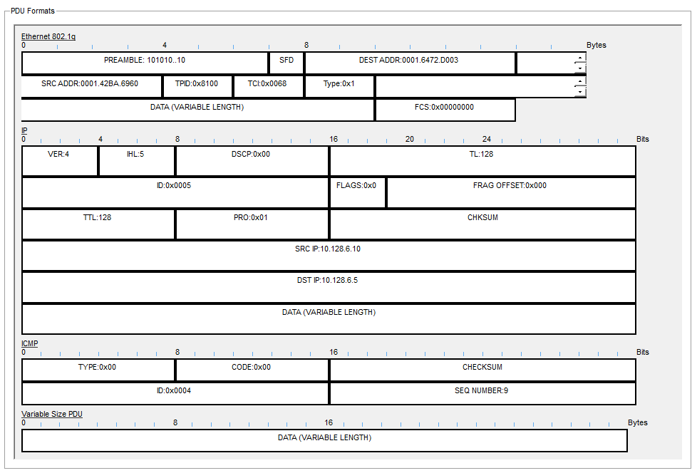

Структура ICMP-ответа

# Итоги работы

## Вывод

В ходе лабораторной работы:

- настроена топология сети в Cisco Packet Tracer;
- назначены статические IP-адреса узлам сети;
- создана база VLAN и выполнено именование виртуальных сетей;
- настроен VTP-сервер и VTP-клиенты;
- настроены trunk-порты на коммутаторах;
- проверена связность узлов с помощью ping;
- исследована передача ICMP-пакетов в режиме Simulation.

Получены практические навыки настройки VLAN, VTP и анализа сетевого трафика в локальной сети.